# 1 Introduction

### 4.3) Interest Rate vs Dwelling Expenses

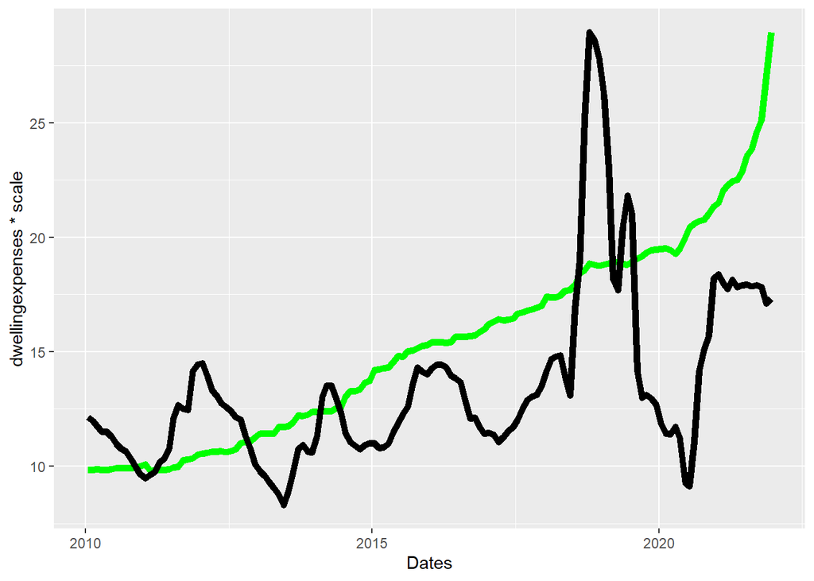

```r
scale<- max(alldata$konutinterest)/max(alldata$dwellingexpenses)

ggplot(data=alldata, aes(x=Dates))+geom_line(aes(y=dwellingexpenses*scale),size=2,colour="#00FF00")+ geom_line(aes(y=konutinterest),size=2)
```

### 4.4) The Price of Unit House vs Google Trends Data for “Konut Kredisi”

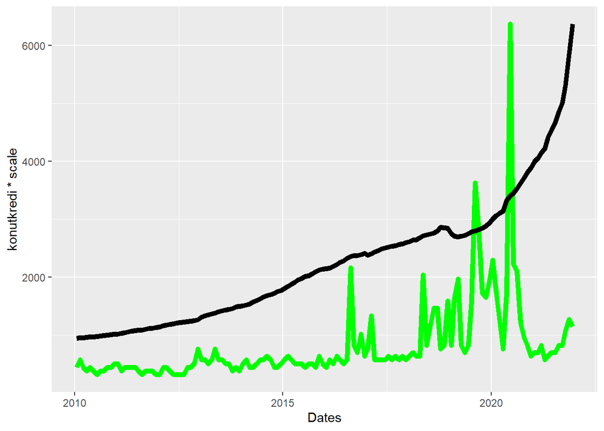

```r
scale<- max(alldata$konutfiyat)/max(alldata$konutkredi)

ggplot(data=alldata, aes(x=Dates))+geom_line(aes(y=konutkredi*scale),size=2,colour="#00FF00")+ geom_line(aes(y=konutfiyat),size=2)
```

The key word “Konut Kredisi” has taken on a seasonal character after 2016. this shows an increasing trend in addition to seasonality. There is also an increasing trend in house prices, but it cannot be said that the rates are at similar values.

# 4) Conclusion

The Price of Unit House have a strong correlation with dwelling expenses. There is a moderate correlation between price of unit house and interest rates. However there is no evidence for strong correlation between price of unit house and the search of “Konut Kredisi” keyword.